# Supplementary material of the manuscript

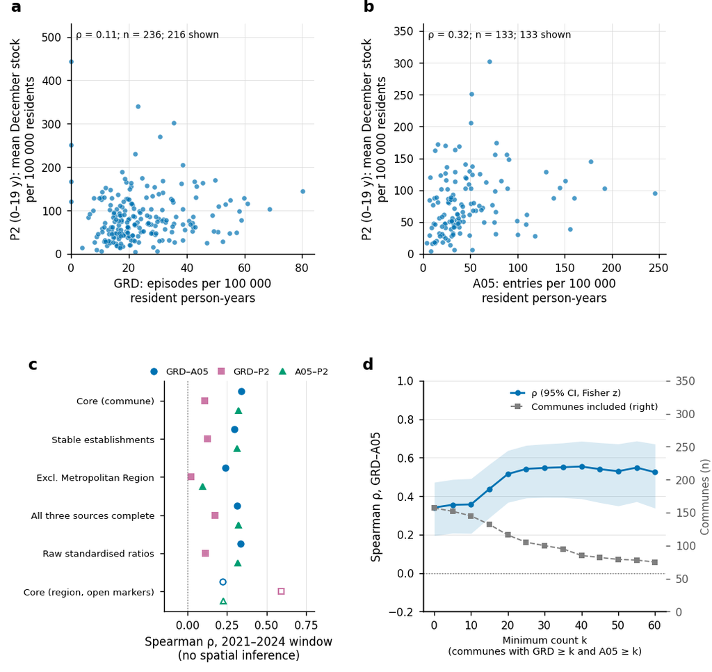

**Figure S7. Ecological correlations between systems in the common 2021–2024 window and their sensitivity.** (a) GRD eligible episodes per 100 000 resident person-years against the P2 December stock (ages 0–19) per 100 000 mean all-age residents, by commune. (b) A05 strict-autism entries per 100 000 resident person-years against the same P2 stock. GRD is located by residence and REM by the reporting establishment; at least one valid REM value in every year was required, absent reporting was not imputed as zero, and communes with positive counts of 1–4 in either source are not displayed. (c) Spearman coefficients for the three source pairs at the commune scale under the core analysis and four sensitivity analyses (stable establishments only, excluding the Metropolitan Region, communes complete in all three sources, and raw rather than smoothed standardised ratios), and at the regional scale (open markers). (d) The GRD–A05 coefficient when both sources are restricted to communes with at least k records, with Fisher-z 95% intervals and the number of communes retained. These are descriptive coefficients without spatially adjusted inference; they do not establish individual concordance, referral, prevalence or causality. Abbreviations: GRD=diagnosis-related groups; REM=Monthly Statistical Summaries; A05, P2=REM modules; A05=REM mental-health entry module; P2=REM child/adolescent special-health-needs follow-up module; CI=confidence interval.

Plate files (175 mm, 300 dpi): PNG · SVG · PDF

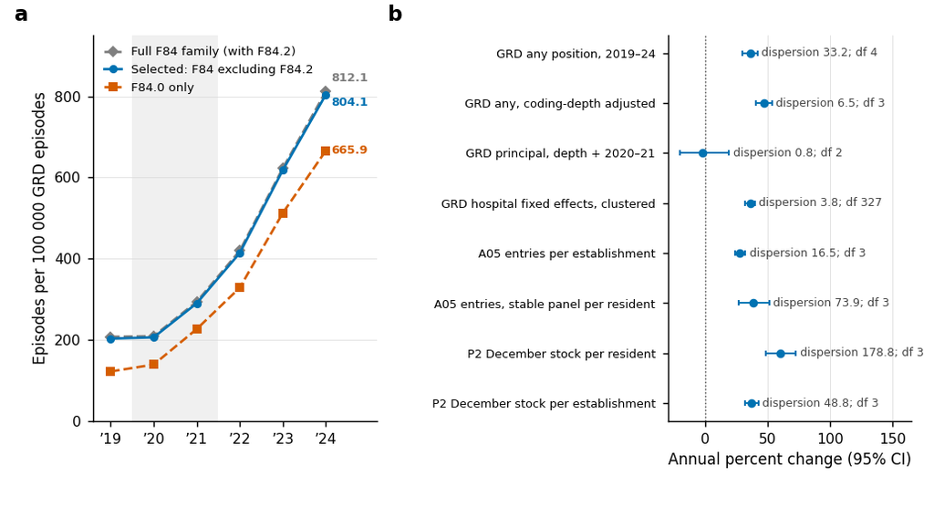

**Figure S8. Case definition and diagnostics of the selected trend models.** (a) The selected definition (F84 excluding F84.2) beside the full F84 family, which adds Rett syndrome, and beside F84.0 alone, all on the same observed hospital panel and the same episode denominator. (b) Annual percent change and Wald 95% interval for each model reported in the article, with the Pearson dispersion and the residual degrees of freedom beside it. Specifications fitted to six annual observations have few residual degrees of freedom, and the principal-diagnosis specification with two degrees of freedom is retained despite its imprecision; dispersion far above one is why quasi-Poisson variance was used. These are descriptive trend summaries, not estimates of an intervention effect. Abbreviations: GRD=diagnosis-related groups; A05, P2=REM modules; df=residual degrees of freedom; CI=confidence interval; REM=Monthly Statistical Summaries; A05=REM mental-health entry module; P2=REM child/adolescent special-health-needs follow-up module.

Plate files (175 mm, 300 dpi): PNG · SVG · PDF

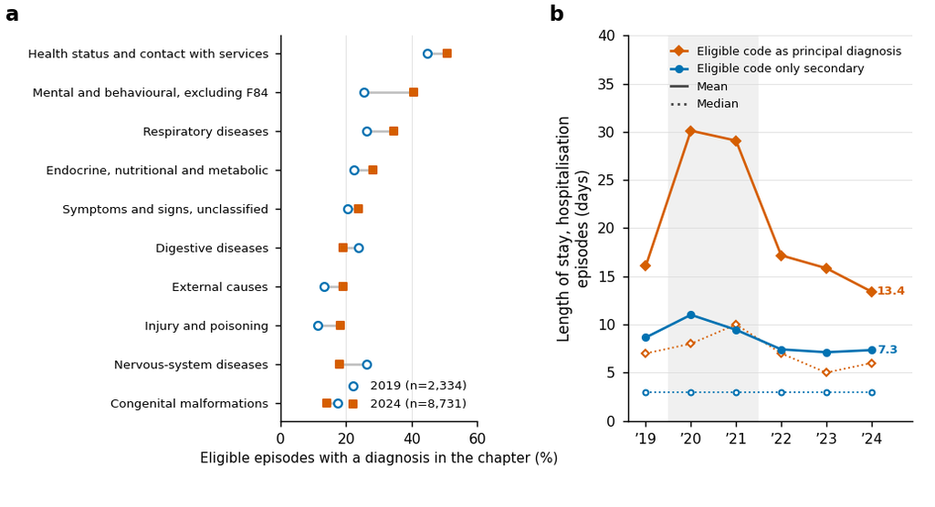

**Figure S9. Clinical detail of eligible hospital episodes: accompanying diagnostic chapters and length of stay by diagnostic position.** (a) Non-F84 ICD-10 chapters recorded in any position during eligible episodes, 2019 and 2024, as a percentage of eligible episodes; the ten most frequent 2024 chapters are retained in both years, chapters overlap, and each episode contributes once per chapter. (b) Mean (solid) and median (dotted) length of stay of hospitalisation episodes with the eligible code as principal diagnosis and with the code only in secondary positions. Observed proportions and means have no sampling intervals, are not standardised for age, case mix or hospital, and are not clinically validated comorbidity estimates. Grey shading marks 2020–2021. Abbreviations: ICD-10=International Classification of Diseases, tenth revision; GRD=diagnosis-related groups.

Plate files (175 mm, 300 dpi): PNG · SVG · PDF

## References

1. Fondo Nacional de Salud. Datos abiertos: financiamiento y gastos en salud; bases de datos GRD de hospitales públicos, 2019–2024. Santiago: FONASA; 2025. https://datosabiertos.fonasa.cl/dimensiones-financiamientos/ (accessed September 4, 2026).
2. Departamento de Estadísticas e Información de Salud, Ministerio de Salud de Chile. Datos abiertos: Reporte Estadístico Mensual (REM), series A y P y diccionarios anuales, 2019–2025. Santiago: Ministerio de Salud; 2026. https://deis.minsal.cl/#datosabiertos (accessed September 4, 2026).
3. Instituto Nacional de Estadísticas. Estimaciones y proyecciones de población 2002–2035, base 2017: comuna, sexo y edad. Santiago: INE; 2019. https://www.ine.gob.cl/estadisticas-por-tema/demografia-y-poblacion/estimaciones-y-proyecciones-de-poblacion (accessed September 10, 2026).
4. Ahmad OB, Boschi-Pinto C, Lopez AD, Murray CJL, Lozano R, Inoue M. Age standardization of rates: a new WHO standard. GPE Discussion Paper Series No. 31. Geneva: World Health Organization; 2001. https://cdn.who.int/media/docs/default-source/gho-documents/global-health-estimates/gpe_discussion_paper_series_paper31_2001_age_standardization_rates.pdf (accessed September 10, 2026).
5. Fay MP, Feuer EJ. Confidence intervals for directly standardized rates: a method based on the gamma distribution. Stat Med 1997; 16: 791–801.
6. Wedderburn RWM. Quasi-likelihood functions, generalized linear models, and the Gauss–Newton method. Biometrika 1974; 61: 439–447.
7. Ministerio de Desarrollo Social y Familia; Servicio Nacional de la Discapacidad. Documento metodológico: Encuesta Nacional de Discapacidad y Dependencia 2022 (ENDIDE). Santiago: Ministerio de Desarrollo Social y Familia; 2023. https://observatorio.ministeriodesarrollosocial.gob.cl/endide-2022 (accessed September 10, 2026).
8. Ministerio de Salud de Chile. Manual de uso de base de datos y libro de códigos: Encuesta Nacional de Calidad de Vida y Salud 2023–2024. Santiago: Ministerio de Salud; 2025. https://datos.gob.cl/dataset/encavi-2023-24 (accessed September 10, 2026).
9. Lumley T. Analysis of Complex Survey Samples. J Stat Softw 2004; 9: 1–19.
10. Arias P, Figueroa I, Pérez J. Análisis longitudinal de la base de datos de la matrícula del Programa de Integración Escolar (PIE), 2019–2023. Apuntes 60. Santiago: Centro de Estudios MINEDUC; 2024. https://bibliotecadigital.mineduc.cl/handle/20.500.12365/21105 (accessed September 4, 2026).
11. Subsecretaría de Educación Superior, Ministerio de Educación de Chile. Informe Ley N° 21.545: estado de su implementación en Educación Superior. Santiago: Ministerio de Educación; 2026. https://educacionsuperior.mineduc.cl/wp-content/uploads/sites/49/2026/03/Reporte_LEY21545_SINACES.pdf (accessed September 4, 2026).
12. Marshall RJ. Mapping Disease and Mortality Rates Using Empirical Bayes Estimators. J R Stat Soc Ser C Appl Stat 1991; 40: 283–294.
13. Moran PAP. Notes on Continuous Stochastic Phenomena. Biometrika 1950; 37: 17–23.
14. Anselin L. Local Indicators of Spatial Association—LISA. Geogr Anal 1995; 27: 93–115.
15. Benjamini Y, Hochberg Y. Controlling the False Discovery Rate: A Practical and Powerful Approach to Multiple Testing. J R Stat Soc Ser B Methodol 1995; 57: 289–300.